# Explore_Many_Variables_R_Udacity

Aniko Lengyel

I analyzed Udacity’s pseudo-Facebook data based on the course instructions. I used an rmd file to show and track the whole analyzis process.

I red in the dataset and looked at the strucure.

```
##  [1] "userid"                "age"
##  [3] "dob_day"               "dob_year"
##  [5] "dob_month"             "gender"
##  [7] "tenure"                "friend_count"
##  [9] "friendships_initiated" "likes"
## [11] "likes_received"        "mobile_likes"
## [13] "mobile_likes_received" "www_likes"
## [15] "www_likes_received"
```

```
##    userid age dob_day dob_year dob_month gender tenure friend_count
## 1 2094382  14      19     1999        11   male    266            0
## 2 1192601  14       2     1999        11 female      6            0
## 3 2083884  14      16     1999        11   male     13            0
## 4 1203168  14      25     1999        12 female     93            0
## 5 1733186  14       4     1999        12   male     82            0
## 6 1524765  14       1     1999        12   male     15            0
##   friendships_initiated likes likes_received mobile_likes
## 1                     0     0              0            0
## 2                     0     0              0            0
## 3                     0     0              0            0
## 4                     0     0              0            0
## 5                     0     0              0            0
## 6                     0     0              0            0
##   mobile_likes_received www_likes www_likes_received
## 1                     0         0                  0
## 2                     0         0                  0
## 3                     0         0                  0
## 4                     0         0                  0
## 5                     0         0                  0
## 6                     0         0                  0
```

I created a new data frame, called ‘pf.fc_by_age_gender’, that contains information on each age and gender group, including the following variables:

- mean_friend_count,
- median_friend_count,
- n (the number of users in each age and gender grouping)

[output not shown]

I created a line graph to show the median friend count over the ages for each gender in the pf.fc_by_age_gender data frame.

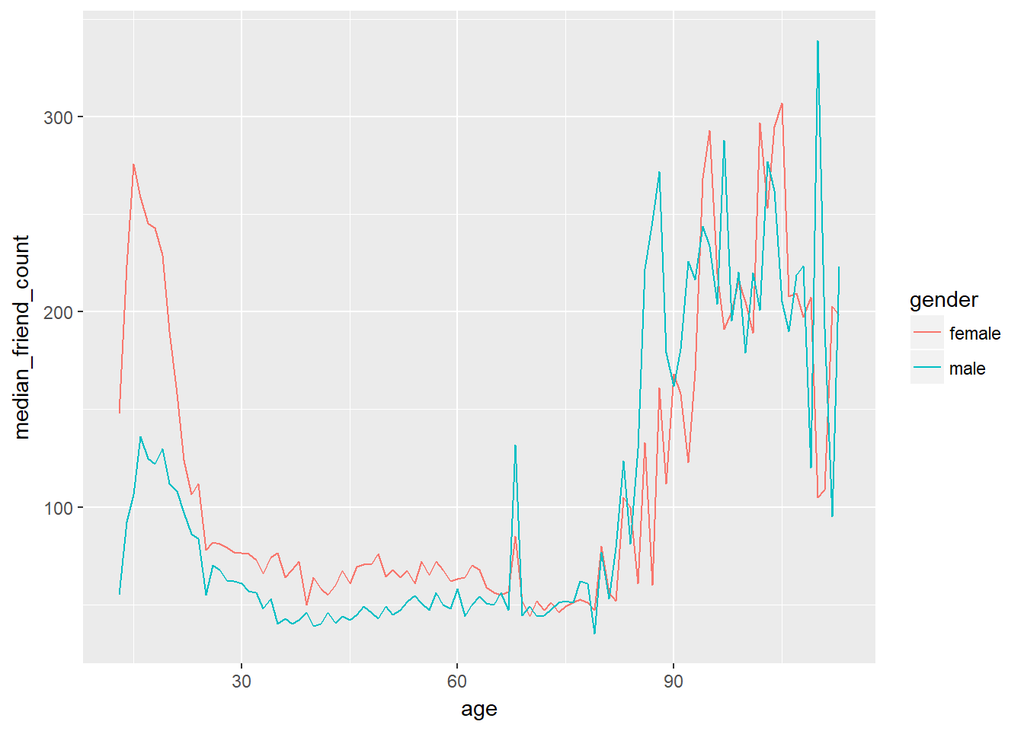

Using package “tidyr”.

```
## # A tibble: 101 x 4
## # Groups: age [101]
##      age female  male `<NA>`
##    <int>  <dbl> <dbl>  <dbl>
##  1    13    148  55.0   NA
##  2    14    224  92.5   NA
##  3    15    276 106    116
##  4    16    258 136     NA
##  5    17    246 125    106
##  6    18    243 122     NA
##  7    19    229 130    374
##  8    20    190 112     65.0
##  9    21    158 108     79.0
## 10    22    124  97.0   NA
## # ... with 91 more rows
```

I reshaped the data with dcast function, and excluded the records where there is no data about the genders. I also created a new dataframe, named pf.fc_by_age_gender.wide.

```
##   age female  male
## 1  13  148.0  55.0
## 2  14  224.0  92.5
## 3  15  276.0 106.5
## 4  16  258.5 136.0
## 5  17  245.5 125.0
## 6  18  243.0 122.0
```

I plotted the ratio of the female to male median friend counts and added a horizontal line to the plot with a y intercept and made it dashed. I arranged the plots to get two diagram based on gender.

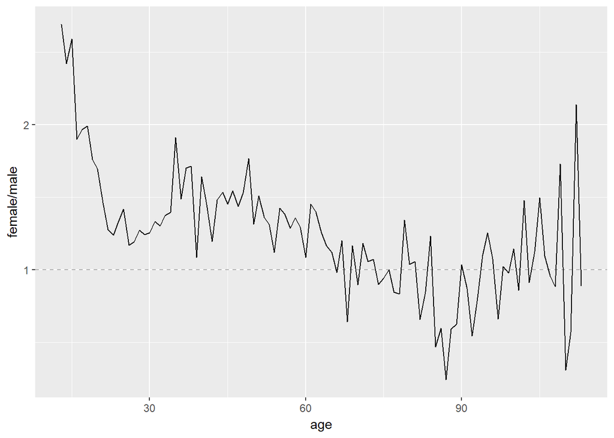

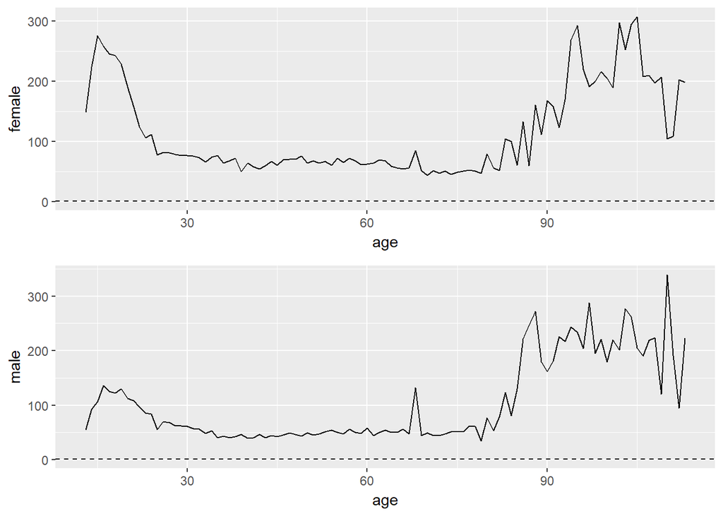

I created a new variable, called year_joined in the pf data frame using the variable tenure. 2014 is the last year.

According to the instructions, the variable year_joined had to contain the year that a user joined facebook.

```
##    Min. 1st Qu.  Median    Mean 3rd Qu.    Max.    NA's
##    2005    2012    2012    2012    2013    2014       2
```

Doublecheking the numbers of users joined in each year.

```
##
##  2005  2006  2007  2008  2009  2010  2011  2012  2013  2014
##     9    15   581  1507  4557  5448  9860 33366 43588    70
```

I created a new variable in the data frame called year_joined.bucket by using the cut function on the variable year_joined.

I had to create the following buckets for the new variable, year_joined.bucket.

```
    (2004, 2009]
    (2009, 2011]
    (2011, 2012]
    (2012, 2014]
```

I had to create a line graph of friend_count vs. age so that each year_joined.bucket is a line tracking the median user friend_count across age.

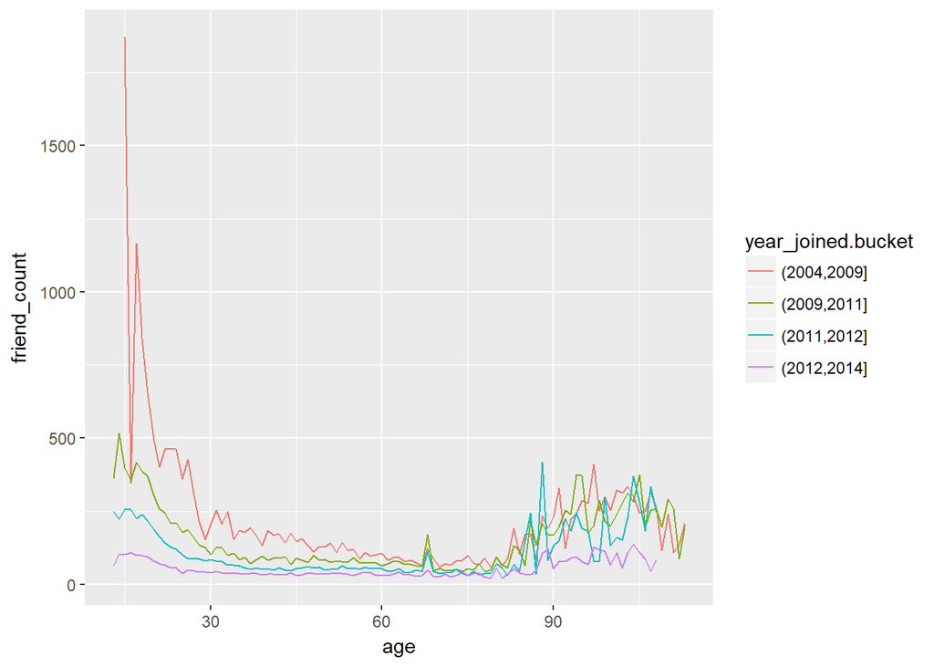

After that I followed the instructions below:

1. Add another geom_line to code below to plot the grand mean of the friend count vs age.
2. Exclude any users whose year_joined.bucket is NA.
3. Use a different line type for the grand mean.

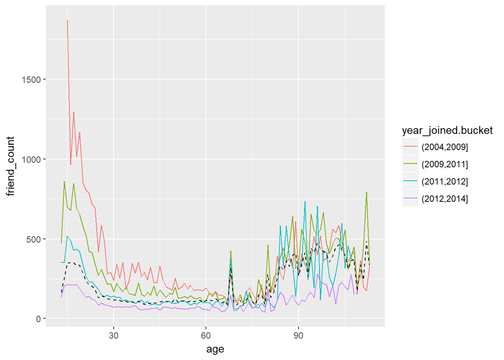

```
##     Min.  1st Qu.   Median     Mean  3rd Qu.     Max.
##   0.0000   0.0775   0.2205   0.6096   0.5658 417.0000
```

I created a graph of mean of friendships_initiated per day (of tenure) vs. tenure colored by year_joined.bucket. I exluded the users with less than one day of tenure.

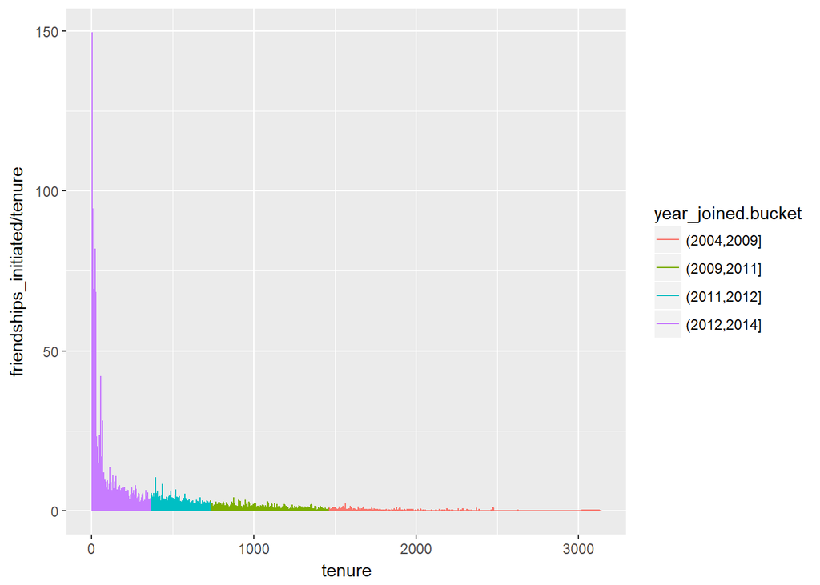

I limited the y axis to get a better readable diagram.

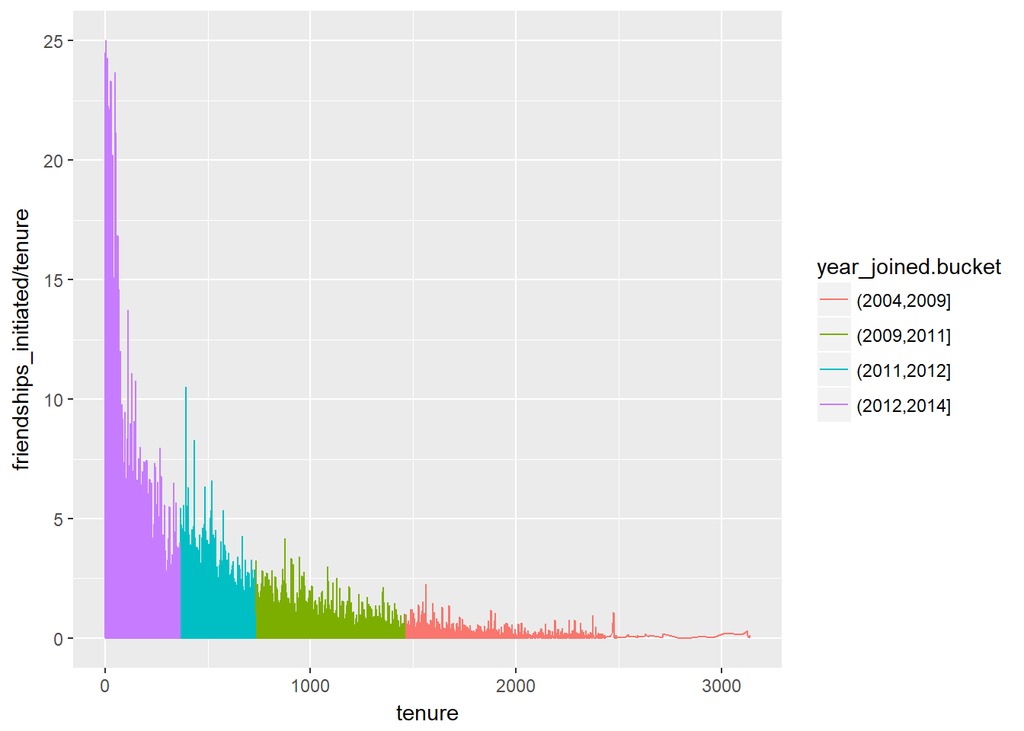